# Online Censorship: An Insiduous Trigger for Internet Shutdowns in Africa?

Augustine Malija(a.malija@mpp.hertie-school.org) and Kindye Atnafu Adugna(k.adugna@mpp.hertie-school.org)

12/22/2020

**Authors’ Contribution**

Augustine’s contribution on this blog started by contacting the Mo Ibrahim Foundation to obtain the recent data on time. He also worked on scrapping the web, visualizing the continental average summary and state of internet shutdowns, extracting the relationship between public participation and economic opportunities, creating the interaction and density plots on RStudio as well as on the final report. He also co-wrote the final report and prepared the final presentation.

Kindye’s contribution was in following up with experts to access the latest data, extracting the average summary for continental repression, visualizing the trajectories of the top and least performing countries using density plots and the coefficient plot to see the impact of selected variables on elections. He co-wrote the final report and prepared a script for the final presentation.

**Synopsis**

**Introduction**

For a decade, economic performance in African countries has seen a continual improvement. This has mainly been driven by governments prioritizing investments in economic growth sectors such as infrastructure and ease of market access for agricultural produce. Accounting for other dimensions, what does this narrate about governance in general? On average, opinion from government representatives paints a rosy picture of improvements. But residents’ public opinion tells a different story.

**Analysis**

Our main dimensions of interest were Participation, Rights, and Inclusion together with Foundations for Economic Opportunity. We scrapped the web for generated scores data that we combined with population data on African countries from Worldometer to explain various phenomena. One striking finding from the report is that the effect of COVID-19 has steepened the already worsening governance situation for the past years. Our intrigue led us to find out if this is the case and/or if there are additional factors. Corollary, we picked representative variables for our two dimensions of interest; absence of internet shutdowns, freedom of association and assembly, unrestricted access to internet content, inequality mitigation, social-economic opportunity by social groups, just to mention a few.

To plot the performance of select variables, we calculate average scores from countrywise scores in a given year to have one single average score per variable. We then transform data to a longer format for ease plotting of variables across time.

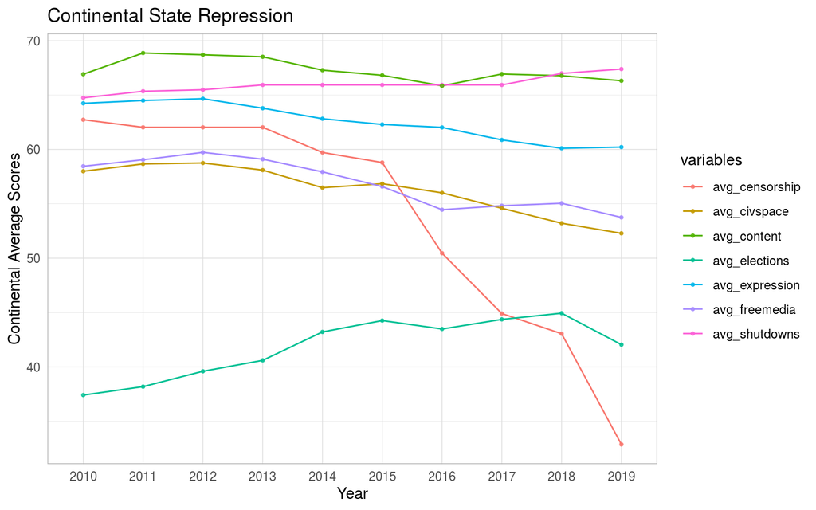

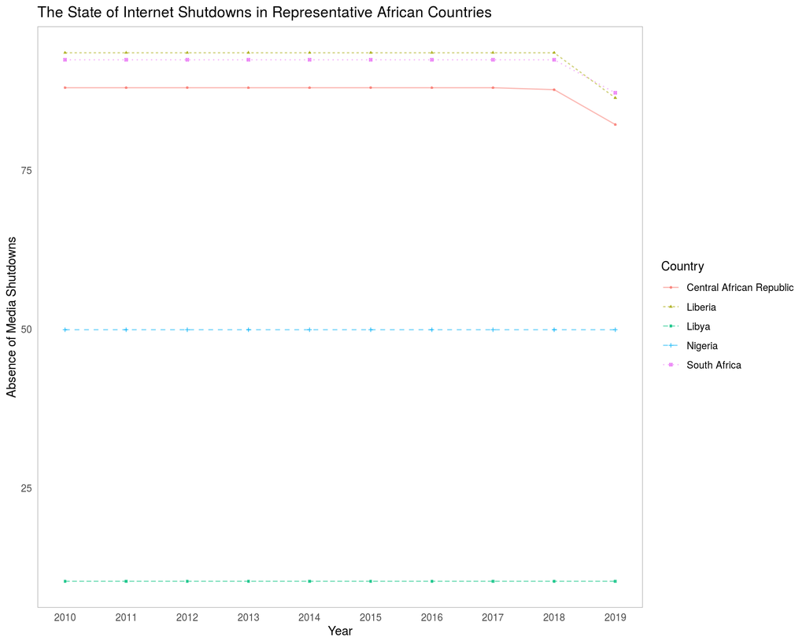

Curious about telling the relationship between economic performance and citizen participation. We use a scatter plot to visualize Foundations for Economic Opportunity against Participation, Rights, and Inclusion.

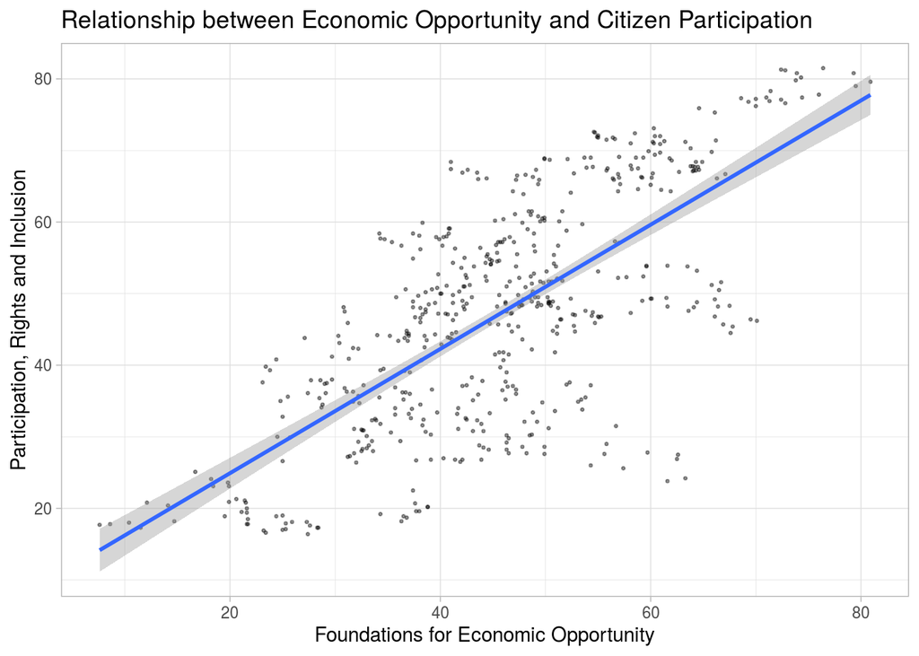

As seen from the scatter plot, countries that perform better economically seem to also perform better in participation, rights, and inclusion.

Considering all four dimensions, we plot nine best performing countries. We calculate an average of the four dimensions, arrange them in a descending order, generate ranks, single out the nine best-performing countries and plot them in a vertical bar chart.

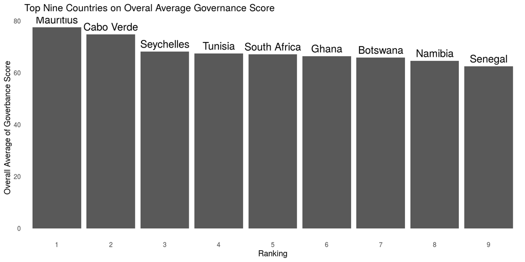

Mauritius and Cabo Verde top the list followed by the rest. As it stands, the top nine countries have been better in all dimensions for the past years.

Surprisingly, the two least performing countries (Somalia and Eritrea) have seen an improvement in performance based on all indicators for the past decade. Even though their governance scores are very low, they are better evolving compared to those of the two top-performing countries. To show this, we select the two top-performing and two least performing countries based on the overall governance score. We then put them into two categories, Top Performing and Least Performing to be able to show this trajectory through density plots.

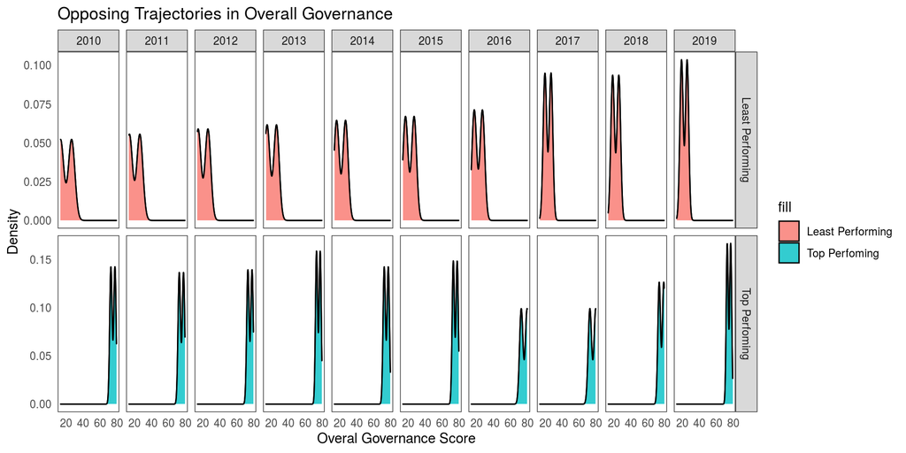

As seen from the density plots. The average improvement in governance scores for Least performing countries has been significant compared to top-performing ones that have been on a concerning path of deterioration since 2015. Representing top-performing countries, Mauritius’ deterioration is due to a weakening social protection and a deteriorating environment for human rights. On the flipside, Somalia’s improvement in governance score is explained by its improvement in infrastructure and increased gender equality.

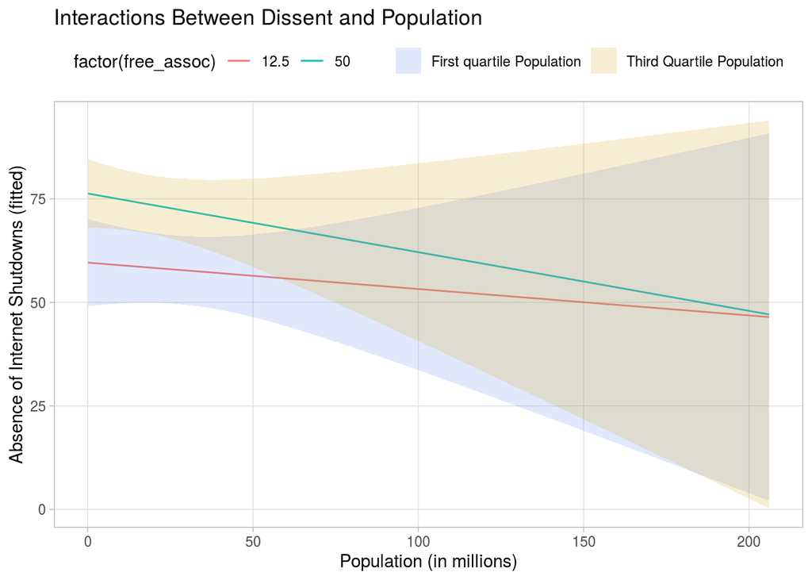

As we can see from the plot, the absence of social media and internet shutdowns decreases as the population increases. In other words, citizens are more likely to dissent in populous countries and thus are subject to state repression through internet shutdowns. This is in tandem with countries such as Nigeria, Ethiopia, and Tanzania topping the list as the most populous countries in the continent. Although Tanzania conducted its democratic elections, there were internet shutdowns for about two weeks during the election time until results were out. The main motive for this was to discourage demonstrations from citizens who claimed that the elections were not free and fair. Equally likely, Ethiopia’s postponement of democratic elections led to some parts of the country demanding elections. This led to the government’s repression through shutting down the internet for a couple of weeks among other things. The same is true in Nigeria’s #EndSARS protest. The government shut the internet to control the continuous movement against Nigerian Special Anti-Robbery Squad (SARS) police forces’ brutality. The slogan started as a Twitter campaign but spread to streets. Hence, the government’s response was shutting down some social media platforms to limit communication among protestors.

We selected political pluralism, freedom of expression, foundations for economic opportunity, civil society space, and censorship as independent variables to explain the likelihood of conducting democratic elections.

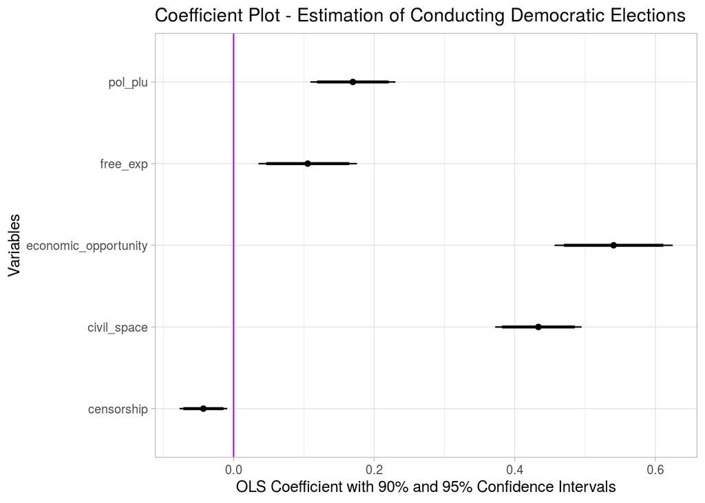

From our output, all except online censorship have a positive impact. Keeping other things constant, a 1-point increase in political pluralism increases the chance of holding democratic elections by 0.16 points. Countries such as Ghana and South Africa are good examples of how their political pluralism led to a successful democratic election in the last 2-3 years. On the other hand, countries such as Eritrea and Rwanda, where the government suppresses and detains opposition parties, have had no free and fair elections in the last 10 years.

A one-point increase in civil society space increases the chance of holding a democratic election by 0.43. Many African countries have strict laws towards civil societies. The most popular one, for example, is the Ethiopian 70:30 regulation. It requires civil society organizations to collect 70% of their funds from local sources, which is very difficult in countries where the average income of the country is below $235/month. Strong foundations for economic opportunities in democratic elections plays a big role. As many economic opportunities are created in urban areas (non-agrarian places) - it is also a proxy variable for cities. Cities with better economies are more likely to conduct democratic elections compared to cities with low economic opportunities. Unlike many Western countries, economic opportunities come with access to information; being independent of government charities (they are given only if people support the government), and other factors.

Freedom of expression has a positive relationship with democratic elections. A one-point increase leads to a 0.1 point increase in conducting democratic elections. All the explanatory variables are significant at a 95% confidence interval. The negative relationship Online censorship has with elections is due to it’s insidious effect that has been prevailing throughout the decade. Slowly restricting access to select internet content pushes for state inneficiencies like postponement of democratic elections.

**Conclusion**

Although internet shutdowns have gained popularity as a present day form of government repression, it is one of the ripple effects of online censorship. Our closer look found that this root for state repression has been present since the beginning of the past decade - and has been increasing significantly particularly from the year 2015. As a festering governance wound, it has led to internet shutdowns, declines in freedom of expression, media freedom and associated indicators for participation, rights and inclusion together with foundations for economic opportunity. This calls for engaging governance - ones that are willing to listen to opposing ideas and forge a way forward.